# Medical Student Attitudes Toward Personalized Medicine Report

Kipp Johnson

May 19, 2015

## 0.1 Introduction

This analysis is conducted in R using R Markdown with Knitr for report generation. The raw data as well as the source code for every table, figure, and calculation is accessible at https://www.github.com/kippjohnson/PMQ/

Much of the actual analysis code is omitted from being embedded in the printout of this report because it’s tedious to look at along with the results. However, it is completely available in the markdown file in the Github repository (ProjectReport.Rmd).

If you are trying to replicate this report, ensure the following R packages are installed and loaded:

```r
library(knitr) # For report generation, not strictly necessary to run code
library(psych)
library(dunn.test)
library(plyr) # for ddply and mutate function
library(ggplot2)
library(gridExtra)
```

R code for reading in the data from the Github Repository (/kippjohnson/PMQ):

```r
rm(list=ls()) #clear memory at start
tmp <- tempfile()
download.file("https://raw.githubusercontent.com/kippjohnson/PMQ/master/SurveyResponses.csv", destfile=tmp, method="curl")
infile <- read.csv(tmp,header=TRUE)
```

## 0.2 Survey Demographics Table

### 0.2.1 EBPAS Statistics

The first step is to compute EBPAS total score, along with its subsets for scores of openness and divergence. Education is not included in the EBPAS. Questions 1-12 excluding 3, 6, 9, and 11 define the EBPAS scale on the survey. 3, 6, 9, and 11 are the education questions. There are a number of people who did not completely fill out the first 12 questions of the survey, and for the analysis they will be dropped because we have a large enough number of respondents without them.

Questions 2, 4, 5, and 8 are ‘divergence’ questions, where the questions have answers which have been formulated to be the inverse of the answering scale. They have been reversed in our analysis.

```r
infile2 <- mutate(infile, total1to12 = Q1+Q2+Q3+Q4+Q5+Q6+Q7+Q8+Q9+Q10+Q11+Q12)
infile3 <- infile2[-which(is.na(infile2$total1to12)),] #drop incompletes
```

Number of people who did not completely fill out the first 12 questions on the survey: **17**

Questions here: Do you agree with my decision to drop **17** individuals from the rest of the study? I think it was the best way to proceed, because we have a large number of responses without them and it makes everything harder and less reliable if we choose to proceed with a large amount of missing data.

#### 0.2.1.1 **Initial** Cronbach’s Alpha Calculations

For Cronbach’s alpha, we use the alpha() function from the psych package in R. The EBPAS cronbach’s alpha is taken from the literature {0.78} (Overby et al., J Pers. Med. 2014), as was done in the paper from which we are modeling this.

|  | N | Mean | SD | Min | Max | Range | Alpha |
| --- | --- | --- | --- | --- | --- | --- | --- |
| EBPAS | 195 | 24.800 | 3.506 | 16 | 36 | 20 | 0.780 |
| education | 195 | 10.610 | 2.490 | 5 | 17 | 12 | 0.545 |
| divergence | 195 | 9.713 | 2.561 | 4 | 18 | 14 | 0.545 |
| openness | 195 | 15.087 | 2.949 | 5 | 20 | 15 | 0.814 |

The Cronbach’s alpha for the combined openness & divergence is 0.6869655.

#### 0.2.1.2 Cronbach’s alpha for different possible 3-question subsets of education

From the education questions 3, 6, 9, and 11, we can make four different possible subsets of three questions: 3, 6, 9; 3, 9, 11; 3, 6, 11; 6, 9, 11. Here, we compute the Cronbach’s alpha for these possible subsets of questions.

```
## Some items ( Q9 ) were negatively correlated with the total scale and probably should be reversed.  To do this, run the function again with the 'check.keys=TRUE' option
```

[output not shown]

As you can see, none of these are above 0.70, although the grouping of questions 3, 6, and 11 is close. Apparently question number 9 elicited different responses from the other three educational questions. We we do later find a different association for number 9 with our covariates than we do for questions 3, 6, and 11.

### 0.2.2 Computing Cronbach’s alpha for questions 18-21, 22-25, and 18-25 combined.

Questions 18-21 ask the subject “How comfortable are you in your knowledge about [various genomic testing concepts].” Questions 22-25 ask the subject “How comfortable are you in your ability to [apply various genomic testing concepts in a clinical setting]”. We can also combine all 8 questions together as a general genomic familiarity category. To see if these sections assessed the same central ability, we can compute Cronbach’s alpha for each of them:

| Questions 18-21 Alpha | Questions 22-25 Alpha | Questions 18-25 (Combined) Alpha |
| --- | --- | --- |
| 0.9012832 | 0.9272846 | 0.9338605 |

As you can see, the Cronbach’s alpha for these sections are extremely high.

## 0.3 Data Analysis & Significance Tests

#### 0.3.0.1 Frequencies

*Question Response Frequencies*: Tables of each question’s (1-25) response frequency. These questions are categorized as:

- EBPAS & education questions (1-12)
- Attitudes toward DTC (13-15)
- Comfort using technology (16, 17)
- Knowledge of genomic testing concepts (18-21)
- Ability to understand genomic testing concepts (22-25)

The data is coded as follows:

- Questions 1-12: 1=not at all, 2=to a slight extent, 3=to a moderate extent, 4=to a great extent, 5=to a very great extent
- Question 13: 0= no, 1=yes
- Question 14: 1=would not use, 2=would use, 3=did use
- Question 15: 1=strongly disagree, 2=disagree, 3=uncertain, 4=agree, 5=strongly agree
- Questions 16-25: 1=not at all, 2=not very comfortable, 3=neither comfortable nor uncomfortable, 4=comfortable, 5=very comfortable
- Question 26: 1=23 or younger, 2=24-25, 3=26 or older
- Question 27: 0=male, 1=female
- Question 28.1: 0=no, 1=yes
- Question 28.2: 1=MS1, 2=MS2, 3=MS3, 4=MS4
- Question 29.1: 0=no, 1=yes
- Question 29.2: 1=MD/PhD, 2=MD/MPH, 3=MD/MSCR
- Question 30.1: 0=no, 1=yes, 2=Don’t Know
- Question 30.2: 1=Clinical, 2=Translational, 3=Basic Science, 4=Don’t Know (multiple answers were allowed here, e.g. clinical and translational = 12)

**I have currently omitted the response frequency tables for brevity; they can easily be added back into the report if you want.**

### 0.3.1 EBPAS Collapsed T-Tests

Answers for questions 13-25 were tested for an association with EBPAS Score (Questions 1-12 excluding the education questions) using ANOVA followed by Tukey Honest Signficant Differences if called for. After ANOVA, the answers were collapsed into binary categories and T-tests for association with EBPAS score were performed. ANOVA results are not currently shown.

The R output for each ANOVA and Collapsed T-test is shown below. After the end of the output there is a table summarizing the results in a fashion analagous to Table 6 in Overby et al.

The collapsed T-tests were collapsed by assigning the responses in the first three Likert Groups to one group (For example, “Not At All Comfortable, Not Very Comfortable, and Neither Comfortable nor Uncomfortable” were collapsed to *Group 1*), and collapsing the remaining Likery Groups to a second group (“Comfortable and Very Comfortable were assigned to *Group Two*”).

The EBPAS scores totals are approximately normal by visual analysis:

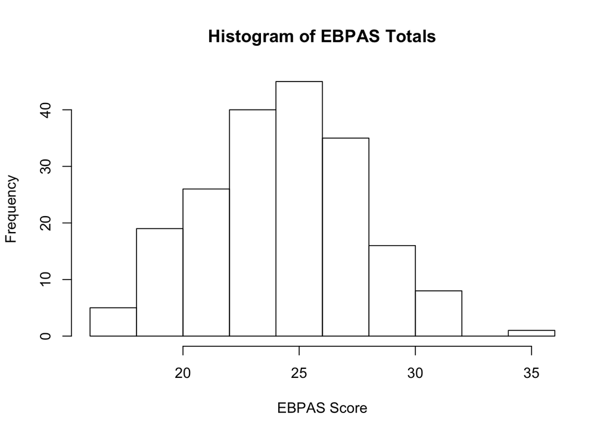

Headings for question 13-25 below are a placeholder in the markdown document in case we want to look at the tests in further detail. Individual results can be shown if needed, but are currently summarized in the below table.

#### 0.3.1.1 Summary Table of Results from Collapsed T-tests (Analagous to Table. 6, Overby et al.)

```
## [1] "Critical P-Value:  " "0.00416666666666667"
```

|  | N | Mean | SD | T-Test P-Value | P-Value Significant? (1=Yes, 0=No) |
| --- | --- | --- | --- | --- | --- |
| Question 13 Group 1 | 155 | 24.761 | 3.273 | 0.798 | 0 |
| Question 13 Group 2 | 155 | 24.761 | 3.273 | 0.798 | 0 |
| Question 14 Group 1 | 69 | 23.913 | 3.733 | 0.014 | 0 |
| Question 14 Group 2 | 120 | 25.267 | 3.365 | 0.014 | 0 |
| Question 15 Group 1 | 124 | 24.266 | 3.386 | 0.006 | 0 |
| Question 15 Group 2 | 69 | 25.739 | 3.584 | 0.006 | 0 |
| Question 16 Group 1 | 10 | 24.200 | 3.490 | 0.589 | 0 |
| Question 16 Group 2 | 185 | 24.832 | 3.514 | 0.589 | 0 |
| Question 17 Group 1 | 93 | 25.000 | 3.483 | 0.448 | 0 |
| Question 17 Group 2 | 102 | 24.618 | 3.535 | 0.448 | 0 |
| Question 18 Group 1 | 88 | 24.273 | 3.324 | 0.055 | 0 |
| Question 18 Group 2 | 107 | 25.234 | 3.607 | 0.055 | 0 |
| Question 19 Group 1 | 130 | 24.123 | 3.373 | 0.000 | 1 |
| Question 19 Group 2 | 65 | 26.154 | 3.397 | 0.000 | 1 |
| Question 20 Group 1 | 108 | 24.296 | 3.526 | 0.020 | 0 |
| Question 20 Group 2 | 86 | 25.465 | 3.398 | 0.020 | 0 |
| Question 21 Group 1 | 129 | 24.434 | 3.475 | 0.034 | 0 |
| Question 21 Group 2 | 65 | 25.569 | 3.482 | 0.034 | 0 |
| Question 22 Group 1 | 169 | 24.479 | 3.395 | 0.004 | 1 |
| Question 22 Group 2 | 25 | 26.920 | 3.639 | 0.004 | 1 |
| Question 23 Group 1 | 149 | 24.416 | 3.451 | 0.006 | 0 |
| Question 23 Group 2 | 46 | 26.043 | 3.432 | 0.006 | 0 |
| Question 24 Group 1 | 157 | 24.580 | 3.474 | 0.082 | 0 |
| Question 24 Group 2 | 38 | 25.711 | 3.541 | 0.082 | 0 |
| Question 25 Group 1 | 175 | 24.543 | 3.447 | 0.004 | 1 |
| Question 25 Group 2 | 20 | 27.050 | 3.284 | 0.004 | 1 |

#### 0.3.1.2 Summary Table of Results from Collapsed T-tests (Analagous to Table. 6, Overby et al.) with FDR P-Value correction

```
##          X1       X2       X3 new_pvals_bh pvalsig
## q13.1   155 24.76129 3.273435   0.79828813       0
## q13.1.1 155 24.76129 3.273435           NA      NA
## q14.1    69 23.91304 3.732761   0.03067222       1
## q14.2   120 25.26667 3.365004           NA      NA
## q15.1   124 24.26613 3.386028   0.01650620       1
## q15.2    69 25.73913 3.583673           NA      NA
```

|  | N | Mean | SD | T-Test P-Value (FDR Adjusted) | P-Value Significant? (FDR Adjustment) (1=Yes, 0=No) |
| --- | --- | --- | --- | --- | --- |
| Question 13 Group 1 | 155 | 24.761 | 3.273 | 0.798288125842446 | 0 |
| Question 13 Group 2 | 155 | 24.761 | 3.273 |  |  |
| Question 14 Group 1 | 69 | 23.913 | 3.733 | 0.0306722238170707 | 1 |
| Question 14 Group 2 | 120 | 25.267 | 3.365 |  |  |
| Question 15 Group 1 | 124 | 24.266 | 3.386 | 0.0165062048136142 | 1 |
| Question 15 Group 2 | 69 | 25.739 | 3.584 |  |  |
| Question 16 Group 1 | 10 | 24.200 | 3.490 | 0.638186075304686 | 0 |
| Question 16 Group 2 | 185 | 24.832 | 3.514 |  |  |
| Question 17 Group 1 | 93 | 25.000 | 3.483 | 0.529505066885666 | 0 |
| Question 17 Group 2 | 102 | 24.618 | 3.535 |  |  |
| Question 18 Group 1 | 88 | 24.273 | 3.324 | 0.0790798981368827 | 0 |
| Question 18 Group 2 | 107 | 25.234 | 3.607 |  |  |
| Question 19 Group 1 | 130 | 24.123 | 3.373 | 0.0017073718080383 | 1 |
| Question 19 Group 2 | 65 | 26.154 | 3.397 |  |  |
| Question 20 Group 1 | 108 | 24.296 | 3.526 | 0.0377430896246357 | 1 |
| Question 20 Group 2 | 86 | 25.465 | 3.398 |  |  |
| Question 21 Group 1 | 129 | 24.434 | 3.475 | 0.0550315832818812 | 0 |
| Question 21 Group 2 | 65 | 25.569 | 3.482 |  |  |
| Question 22 Group 1 | 169 | 24.479 | 3.395 | 0.0159337139226652 | 1 |
| Question 22 Group 2 | 25 | 26.920 | 3.639 |  |  |
| Question 23 Group 1 | 149 | 24.416 | 3.451 | 0.0165062048136142 | 1 |
| Question 23 Group 2 | 46 | 26.043 | 3.432 |  |  |
| Question 24 Group 1 | 157 | 24.580 | 3.474 | 0.106170873895831 | 0 |
| Question 24 Group 2 | 38 | 25.711 | 3.541 |  |  |
| Question 25 Group 1 | 175 | 24.543 | 3.447 | 0.0159337139226652 | 1 |
| Question 25 Group 2 | 20 | 27.050 | 3.284 |  |  |

```
##   Q19c   n     mean
## 1    1 130 24.12308
## 2    2  65 26.15385
```

```
##   Q22c   n     mean
## 1    1 169 24.47929
## 2    2  25 26.92000
## 3   NA   1 26.00000
```

```
##   Q25c   n     mean
## 1    1 175 24.54286
## 2    2  20 27.05000
```

```
##   Q14c   n     mean
## 1    1  69 23.91304
## 2    2 120 25.26667
## 3   NA   6 25.66667
```

```
##   Q15c   n     mean
## 1    1 124 24.26613
## 2    2  69 25.73913
## 3   NA   2 25.50000
```

```
##   Q20c   n     mean
## 1    1 108 24.29630
## 2    2  86 25.46512
## 3   NA   1 22.00000
```

### 0.3.2 Statistical Tests for four education questions

In the previous section, we performed ANOVA and collapsed T tests for the 8 EBPAS questions on the predictor questions 13-25. For the education questions 3, 6, 9, and 11, we cannot combine them into one category because Cronbach’s alpha is <0.7 for them. However, we can analyze the questions individually, as is done here:

##### 0.3.2.0.1 T-Tests for association with Education question 3

```
##
##
##                 P Value   Significant (1=Yes, 0=No)
## ------------  ---------  --------------------------
## Question 13    0.213418                           0
## Question 14    0.414697                           0
## Question 15    0.000214                           1
## Question 16    0.812815                           0
## Question 17    0.000202                           1
## Question 18    0.000553                           1
## Question 19    0.000001                           1
## Question 20    0.005262                           0
## Question 21    0.038303                           0
## Question 22    0.012618                           0
## Question 23    0.000013                           1
## Question 24    0.000075                           1
## Question 25    0.007914                           0
##
##   Q15c   n     mean
## 1    1 124 1.822581
## 2    2  69 2.405797
## 3   NA   2 1.500000
##   Q18c   n     mean
## 1    1  88 1.772727
## 2    2 107 2.233645
##   Q19c   n     mean
## 1    1 130 1.769231
## 2    2  65 2.538462
##   Q23c   n     mean
## 1    1 149 1.832215
## 2    2  46 2.652174
##   Q24c   n     mean
## 1    1 157 1.859873
## 2    2  38 2.710526
```

- Those who answered question 15 (“I know enough about genomic to undestand DTC”) as either strongly/ siagree/disagree/uncertain had a significantly lower agreement with the statement “My medical education has adequately prepared me to practice personalized medicine” than those who answered the question as agree or strongly agree (p=0.000214)
- Those who answered question 18 (“Basic genomic testing concepts and terminology?”) as either not at all comfortable/not very comfortable/neither comfortable nor uncomfortable had a significantly lower agreement with the statement “My medical education has adequately prepared me to practice personalized medicine” than those who answered the question" than those who answered the question as comfortable or very comfortable
- Those who answered question 19 (“Pharmacogenomics?”) as either not at all comfortable/not very comfortable/neither comfortable nor uncomfortable had a significantly lower agreement with the statement “My medical education has adequately prepared me to practice personalized medicine” than those who answered the question" than those who answered the question as comfortable or very comfortable.
- Those who answered question 23 (“Understand genomic test results?”) as either not at all comfortable/not very comfortable/neither comfortable nor uncomfortable had a significantly lower agreement with the statement “My medical education has adequately prepared me to practice personalized medicine” than those who answered the question" than those who answered the question as comfortable or very comfortable.
- Those who answered question 24 (“Explain genomic test results”) as either not at all comfortable/not very comfortable/neither comfortable nor uncomfortable had a significantly lower agreement with the statement “My medical education has adequately prepared me to practice personalized medicine” than those who answered the question" than those who answered the question as comfortable or very comfortable.

##### 0.3.2.0.2 T-Tests for association with Education question 6

```
##   Q15c   n     mean
## 1    1 124 1.612903
## 2    2  69 2.275362
## 3   NA   2 2.000000
##   Q18c   n     mean
## 1    1  88 1.602273
## 2    2 107 2.056075
##   Q19c   n     mean
## 1    1 130 1.623077
## 2    2  65 2.307692
##   Q20c   n     mean
## 1    1 108 1.620370
## 2    2  86 2.151163
## 3   NA   1 1.000000
##   Q21c   n     mean
## 1    1 129 1.674419
## 2    2  65 2.215385
## 3   NA   1 1.000000
##   Q23c   n     mean
## 1    1 149 1.684564
## 2    2  46 2.391304
##   Q24c   n     mean
## 1    1 157 1.732484
## 2    2  38 2.342105
##
##
##                 P Value   Significant (1=Yes, 0=No)
## ------------  ---------  --------------------------
## Question 13    0.116689                           0
## Question 14    0.775538                           0
## Question 15    0.000011                           1
## Question 16    0.615854                           0
## Question 17    0.044441                           0
## Question 18    0.000645                           1
## Question 19    0.000004                           1
## Question 20    0.000107                           1
## Question 21    0.000517                           1
## Question 22    0.007724                           0
## Question 23    0.000110                           1
## Question 24    0.002058                           1
## Question 25    0.005217                           0
```

- Those who answered question number 15 (“I know enought about genetics and genomics to understand DTC”) as either strongly disagree, disagree, or uncertain had a significantly lower agreement with the statement “I know whom to ask questions regarding genomic testing questions” than those who answered the question as agree or strongly agree.
- Those who answered question number 18 (“Basic genomic testing concepts and terminology”) as either not at all comfortable, not very comfortable, or neither comfortable nor uncomfortable had a significantly lower agreement with the statement “I know whom to ask questions regarding genomic testing questions” than those who answered the question as comfortable or very comfortable.
- Those who answered question number 19 as either not at all comfortable, not very comfortable, or neither comfortable nor uncomfortable had a significantly lower agreement with the statement “I know whom to ask questions regarding genomic testing questions” than those who answered the question as comfortable or very comfortable.
- Those who answered question number 20 as either not at all comfortable, not very comfortable, or neither comfortable nor uncomfortable had a significantly lower agreement with the statement “I know whom to ask questions regarding genomic testing questions” than those who answered the question as comfortable or very comfortable.
- Those who answered question number 21 as either not at all comfortable, not very comfortable, or neither comfortable nor uncomfortable had a significantly lower agreement with the statement “I know whom to ask questions regarding genomic testing questions” than those who answered the question as comfortable or very comfortable.
- Those who answered question number 23 as either not at all comfortable, not very comfortable, or neither comfortable nor uncomfortable had a significantly lower agreement with the statement “I know whom to ask questions regarding genomic testing questions” than those who answered the question as comfortable or very comfortable.
- Those who answered question number 24 as either not at all comfortable, not very comfortable, or neither comfortable nor uncomfortable had a significantly lower agreement with the statement “I know whom to ask questions regarding genomic testing questions” than those who answered the question as comfortable or very comfortable.

##### 0.3.2.0.3 T-Tests for association with Education question 9

```
##
##
##                 P Value   Significant (1=Yes, 0=No)
## ------------  ---------  --------------------------
## Question 13    0.905790                           0
## Question 14    0.065679                           0
## Question 15    0.529311                           0
## Question 16    0.899237                           0
## Question 17    0.127942                           0
## Question 18    0.998637                           0
## Question 19    0.777419                           0
## Question 20    0.080652                           0
## Question 21    0.337103                           0
## Question 22    0.307809                           0
## Question 23    0.812732                           0
## Question 24    0.572405                           0
## Question 25    0.382568                           0
```

There were no significant associations using collapsed T-tests for question nine.

##### 0.3.2.0.4 T-Tests for association with Education question 11

```
##
##
##                 P Value   Significant (1=Yes, 0=No)
## ------------  ---------  --------------------------
## Question 13    0.008239                           0
## Question 14    0.170139                           0
## Question 15    0.001945                           1
## Question 16    0.290995                           0
## Question 17    0.018198                           0
## Question 18    0.016118                           0
## Question 19    0.001192                           1
## Question 20    0.339768                           0
## Question 21    0.325608                           0
## Question 22    0.006963                           0
## Question 23    0.016217                           0
## Question 24    0.073376                           0
## Question 25    0.002805                           1
```

- Those who answered question number 15 as either strongly disagree, disagree, or uncertain had a significantly lower agreement with the statement “My professors have encouraged the use of personalized medicine” than those who answered the question as agree or strongly agree.
- Those who answered question number 19 as either not at all comfortable, not very comfortable, or neither comfortable nor uncomfortable had a significantly lower agreement with the statement “My professors have encouraged the use of personalized medicine” than those who answered the question as comfortable or very comfortable.
- Those who answered question number 25 as either not at all comfortable, not very comfortable, or neither comfortable nor uncomfortable had a significantly lower agreement with the statement “My professors have encouraged the use of personalized medicine” than those who answered the question as comfortable or very comfortable.

## 0.4 Covariate Analysis

### 0.4.1 Further EBPAS Analyses (against covariates using ANOVA, Questions 26-31.2)

Because EBPAS score is a vector of integers and is approximately normally distributed, the appropriate test to use here is ANOVA. We are looking now for associations between EBPAS and the covariates.

##### 0.4.1.0.1 Covariate Grouping

We need to create a new grouping from Question 28.2 (Year of medical school). We are just merging the M3 and M4 students into one “clinical” grouping, while coding M1s as “pre-didactic” and M2s as “pre-clinical” as was done in Caroline’s Poster. The new vector we create is called Q28.2c (“c” for collapsed).

```r
infile3$Q28.2c <- infile3$Q28.2
infile3$Q28.2c[infile3$Q28.2c==4] <- 3
clinical_grouping_table <- table(infile3$Q28.2c)
```

In the study, there are 51 pre-didactic students, 63 pre-clinical students, and 79 clinical students.

#### 0.4.1.1 EBPAS ANOVAs

```r
ddply(infile3, ~infile3$Q26, summarize, N=length(EBPAS), mean=mean(EBPAS), SD=sd(EBPAS), range=max(EBPAS)-min(EBPAS))
```

```
##   infile3$Q26  N     mean       SD range
## 1           1 58 25.00000 3.534293    16
## 2           2 75 24.89333 3.427131    18
## 3           3 61 24.55738 3.612592    16
## 4          NA  1 21.00000       NA     0
```

```r
ddply(infile3, ~infile3$Q27, summarize, N=length(EBPAS), mean=mean(EBPAS), SD=sd(EBPAS), range=max(EBPAS)-min(EBPAS))
```

```
##   infile3$Q27   N     mean       SD range
## 1           0 103 25.03883 3.449701    16
## 2           1  90 24.57778 3.588301    20
## 3          NA   2 22.50000 2.121320     3
```

```r
ddply(infile3, ~infile3$Q28.2c, summarize, N=length(EBPAS), mean=mean(EBPAS), SD=sd(EBPAS), range=max(EBPAS)-min(EBPAS))
```

```
##   infile3$Q28.2c  N     mean       SD range
## 1              1 51 24.76471 3.461723    16
## 2              2 63 25.11111 3.724856    17
## 3              3 79 24.49367 3.381220    16
## 4             NA  2 28.00000 0.000000     0
```

```r
ddply(infile3, ~infile3$Q29.1, summarize, N=length(EBPAS), mean=mean(EBPAS), SD=sd(EBPAS), range=max(EBPAS)-min(EBPAS))
```

```
##   infile3$Q29.1   N     mean       SD range
## 1             0 164 24.81098 3.461568    20
## 2             1  29 24.93103 3.816609    16
## 3            NA   2 22.00000 2.828427     4
```

```r
ddply(infile3, ~infile3$Q29.2, summarize, N=length(EBPAS), mean=mean(EBPAS), SD=sd(EBPAS), range=max(EBPAS)-min(EBPAS))
```

```
##   infile3$Q29.2   N     mean       SD range
## 1             1  16 25.62500 3.422962    13
## 2             2   6 25.33333 4.273952    12
## 3             3   9 22.22222 3.961621    13
## 4            NA 164 24.84146 3.431966    20
```

```r
infile3$Q30.1c <- infile3$Q30.1
infile3$Q30.1c[infile3$Q30.1c==2] <- 0
infile3$Q30.1c <- as.factor(infile3$Q30.1c)

ddply(infile3, ~infile3$Q30.1c, summarize, N=length(EBPAS), mean=mean(EBPAS), SD=sd(EBPAS), range=max(EBPAS)-min(EBPAS))
```

```
##   infile3$Q30.1c   N     mean       SD range
## 1              0  90 24.77778 3.755977    20
## 2              1 104 24.90385 3.194410    16
## 3           <NA>   1 16.00000       NA     0
```

```
##                         Df Sum Sq Mean Sq F value Pr(>F)
## as.factor(infile3$Q26)   2    6.5   3.245   0.262   0.77
## Residuals              191 2364.2  12.378
## 1 observation deleted due to missingness
```

```
##   Tukey multiple comparisons of means
##     95% family-wise confidence level
##
## Fit: aov(formula = infile3$EBPAS ~ as.factor(infile3$Q26))
##
## $`as.factor(infile3$Q26)`
##           diff       lwr      upr     p adj
## 2-1 -0.1066667 -1.559815 1.346482 0.9835640
## 3-1 -0.4426230 -1.966758 1.081512 0.7719527
## 3-2 -0.3359563 -1.768813 1.096900 0.8446322
```

EBPAS not significantly associated wtih question 26 on ANOVA.

```
##                         Df Sum Sq Mean Sq F value Pr(>F)
## as.factor(infile3$Q27)   1   10.2   10.21   0.826  0.364
## Residuals              191 2359.8   12.36
## 2 observations deleted due to missingness
```

```
##   Tukey multiple comparisons of means
##     95% family-wise confidence level
##
## Fit: aov(formula = infile3$EBPAS ~ as.factor(infile3$Q27))
##
## $`as.factor(infile3$Q27)`
##           diff       lwr       upr     p adj
## 1-0 -0.4610572 -1.461445 0.5393306 0.3644613
```

EBPAS not significantly associated with question 27 on ANOVA.

```
##                            Df Sum Sq Mean Sq F value Pr(>F)
## as.factor(infile3$Q28.2c)   2   13.4   6.681    0.54  0.584
## Residuals                 190 2351.1  12.374
## 2 observations deleted due to missingness
```

```
##   Tukey multiple comparisons of means
##     95% family-wise confidence level
##
## Fit: aov(formula = infile3$EBPAS ~ as.factor(infile3$Q28.2c))
##
## $`as.factor(infile3$Q28.2c)`
##           diff       lwr       upr     p adj
## 2-1  0.3464052 -1.218838 1.9116482 0.8602995
## 3-1 -0.2710350 -1.763684 1.2216142 0.9036243
## 3-2 -0.6174402 -2.021046 0.7861652 0.5531478
```

EBPAS not significantly associated wtih question 28.2c on ANOVA.

```
##                           Df Sum Sq Mean Sq F value Pr(>F)
## as.factor(infile3$Q29.1)   1    0.4   0.355   0.029  0.866
## Residuals                191 2361.0  12.361
## 2 observations deleted due to missingness
```

```
##   Tukey multiple comparisons of means
##     95% family-wise confidence level
##
## Fit: aov(formula = infile3$EBPAS ~ as.factor(infile3$Q29.1))
##
## $`as.factor(infile3$Q29.1)`
##          diff       lwr      upr     p adj
## 1-0 0.1200589 -1.276946 1.517064 0.8655719
```

EBPAS not significantly associated wtih question 29.1 on ANOVA.

```
##                          Df Sum Sq Mean Sq F value Pr(>F)
## as.factor(infile3$Q29.2)  2   70.9   35.45   2.528 0.0979 .
## Residuals                28  392.6   14.02
## ---
## Signif. codes:  0 '***' 0.001 '**' 0.01 '*' 0.05 '.' 0.1 ' ' 1
## 164 observations deleted due to missingness
```

```
##   Tukey multiple comparisons of means
##     95% family-wise confidence level
##
## Fit: aov(formula = infile3$EBPAS ~ as.factor(infile3$Q29.2))
##
## $`as.factor(infile3$Q29.2)`
##           diff       lwr       upr     p adj
## 2-1 -0.2916667 -4.727289 4.1439555 0.9855196
## 3-1 -3.4027778 -7.263491 0.4579357 0.0921228
## 3-2 -3.1111111 -7.994570 1.7723481 0.2723088
```

EBPAS not significantly associated wtih question 29.2 on ANOVA.

```
##                           Df Sum Sq Mean Sq F value Pr(>F)
## as.factor(infile3$Q30.1)   2   20.1   10.05   0.839  0.434
## Residuals                191 2287.3   11.97
## 1 observation deleted due to missingness
```

```
##   Tukey multiple comparisons of means
##     95% family-wise confidence level
##
## Fit: aov(formula = infile3$EBPAS ~ as.factor(infile3$Q30.1))
##
## $`as.factor(infile3$Q30.1)`
##           diff       lwr       upr     p adj
## 1-0 -0.5294872 -2.223511 1.1645367 0.7410297
## 2-0 -0.9833333 -2.811136 0.8444698 0.4134274
## 2-1 -0.4538462 -1.779024 0.8713313 0.6979267
```

EBPAS not significantly associated wtih question 30.1 on ANOVA.

```
##                           Df Sum Sq Mean Sq F value Pr(>F)
## as.factor(infile3$Q30.2)   7    116   16.57   1.501  0.172
## Residuals                141   1556   11.04
## 46 observations deleted due to missingness
```

```
##   Tukey multiple comparisons of means
##     95% family-wise confidence level
##
## Fit: aov(formula = infile3$EBPAS ~ as.factor(infile3$Q30.2))
##
## $`as.factor(infile3$Q30.2)`
##                diff         lwr      upr     p adj
## 2-1       0.5166667  -2.1229277 3.156261 0.9988037
## 3-1      -0.3166667  -4.6939387 4.060605 0.9999986
## 4-1      -1.1261905  -3.4659408 1.213560 0.8162945
## 12-1      1.3738095  -1.2182207 3.965840 0.7308905
## 23-1      0.5166667  -6.8316530 7.864986 0.9999988
## 123-1     1.6984848  -1.6545651 5.051535 0.7738244
## 1234-1   -2.4833333 -12.7912788 7.824612 0.9955400
## 3-2      -0.8333333  -5.5919297 3.925263 0.9994206
## 4-2      -1.6428571  -4.6358758 1.350162 0.6943744
## 12-2      0.8571429  -2.3369689 4.051255 0.9913826
## 23-2      0.0000000  -7.5816576 7.581658 1.0000000
## 123-2     1.1818182  -2.6557166 5.019353 0.9806564
## 1234-2   -3.0000000 -13.4755654 7.475565 0.9873123
## 4-3      -0.8095238  -5.4085686 3.789521 0.9994008
## 12-3      1.6904762  -3.0419019 6.422854 0.9560592
## 23-3      0.8333333  -7.5137969 9.180464 0.9999869
## 123-3     2.0151515  -3.1732707 7.203574 0.9321554
## 1234-3   -2.1666667 -13.2088821 8.875549 0.9987846
## 12-4      2.5000000  -0.4511562 5.451156 0.1623139
## 23-4      1.6428571  -5.8396895 9.125404 0.9975062
## 123-4     2.8246753  -0.8131326 6.462483 0.2548161
## 1234-4   -1.3571429 -11.7612018 9.046916 0.9999188
## 23-12    -0.8571429  -8.4223721 6.708086 0.9999688
## 123-12    0.3246753  -3.4802998 4.129650 0.9999955
## 1234-12  -3.8571429 -14.3208244 6.606539 0.9481349
## 123-23    1.1818182  -6.6767451 9.040382 0.9997887
## 1234-23  -3.0000000 -15.5206954 9.520695 0.9956884
## 1234-123 -4.1818182 -14.8595031 6.495867 0.9292490
```

EBPAS not significantly associated wtih question 30.2 on ANOVA.

### 0.4.2 Education Question Covariate Analysis

I elected to use the Kruskal-Wallis test on the Likert Data instead of ANOVA. Chi-Square assumptions are usually not met without further grouping. KW test is a non-parametric version of one-way ANOVA appropriate here because of ordinal data. The results are summarized in the table below. Correction was done for multiple testing.

##### 0.4.2.0.1 Question 3

See table below, output omitted for brevity

##### 0.4.2.0.2 Question 6

See table below, output omitted for brevity

##### 0.4.2.0.3 Question 9

See table below, output omitted for brevity

##### 0.4.2.0.4 Question 11

See table below, output omitted for brevity

#### 0.4.2.1 Summary Table of Education Question KW Results

```
## [1] "Critical P-Value:  " "0.00714285714285714"
```

Question 3 Covariate Analysis by KW Test

|  | P Value | Significant (1=Yes, 0=No) |
| --- | --- | --- |
| Question 26 | 0.0555645 | 0 |
| Question 27 | 0.0436994 | 0 |
| Question 28.2c | 0.0000000 | 1 |
| Question 29.1 | 0.5448823 | 0 |
| Question 29.2 | 0.7763493 | 0 |
| Question 30.1 | 0.4410352 | 0 |
| Question 30.2 | 0.1592584 | 0 |

Question 6 Covariate Analysis by KW Test

|  | P Value | Significant (1=Yes, 0=No) |
| --- | --- | --- |
| Question 26 | 0.3533610 | 0 |
| Question 27 | 0.0299733 | 0 |
| Question 28.2c | 0.0006684 | 1 |
| Question 29.1 | 0.1683376 | 0 |
| Question 29.2 | 0.0499756 | 0 |
| Question 30.1 | 0.0339872 | 0 |
| Question 30.2 | 0.4775545 | 0 |

Question 9 Covariate Analysis by KW Test

|  | P Value | Significant (1=Yes, 0=No) |
| --- | --- | --- |
| Question 26 | 0.3322555 | 0 |
| Question 27 | 0.3139667 | 0 |
| Question 28.2c | 0.0185659 | 0 |
| Question 29.1 | 0.6681270 | 0 |
| Question 29.2 | 0.1512478 | 0 |
| Question 30.1 | 0.0039345 | 1 |
| Question 30.2 | 0.2968708 | 0 |

Question 11 Covariate Analysis by KW Test

|  | P Value | Significant (1=Yes, 0=No) |
| --- | --- | --- |
| Question 26 | 0.6469855 | 0 |
| Question 27 | 0.3436676 | 0 |
| Question 28.2c | 0.0000001 | 1 |
| Question 29.1 | 0.9580811 | 0 |
| Question 29.2 | 0.9024287 | 0 |
| Question 30.1 | 0.3134792 | 0 |
| Question 30.2 | 0.3403898 | 0 |

- Question 3 is signficiant for an association with clinical grouping (28.2c)
- Question 6 is signficiant for an association with clinical grouping (28.2c)
- Question 9 is signficiant for an association with interest in a research career (30.1)
- Question 11 is signficiant for an association with clinical grouping (28.2c)

More detail on these significant results in the next section.

#### 0.4.2.2 Post-Hoc Tests on Significant KW Tests

We use the Dunn test to test for pairwise differences following KW significance tests. This is a non-parametric equivalent to the Tukey test folowing ANOVA. The multiple-comparisons correction here is for family-wise error rate (FWER) using the Benjamini-Hochberg method as implemented in the dunn.test R package.

##### 0.4.2.2.1 Question Three:

```
##   Kruskal-Wallis rank sum test
##
## data: x and group
## Kruskal-Wallis chi-squared = 43.8087, df = 2, p-value = 0
##
##
##                            Comparison of x by group
##                              (Benjamini-Hochberg)
## Col Mean-|
## Row Mean |          1          2
## ---------+----------------------
##        2 |   6.105813
##          |    0.0000*
##        3 |   5.620559  -0.831828
##          |    0.0000*     0.2028
```

```
##   Q28.2c     mean median  N
## 1      1 1.411765    1.0 51
## 2      2 2.333333    2.0 63
## 3      3 2.189873    2.0 79
## 4     NA 1.500000    1.5  2
```

For question three’s significant association with clinical year, we find that group 1 (pre-didactic) is significantly different from group 2 and 3 (pre-clinical and clinical). The pre-clinical and clinical groups are not significantly different from each other.

Pre-didactic students are significantly less likely to agree with the statement “My medical education has adequately prepared me to practice personalized medication” than are either pre-clinical or clinical students.

##### 0.4.2.2.2 Question Six:

```
##   Kruskal-Wallis rank sum test
##
## data: x and group
## Kruskal-Wallis chi-squared = 14.6214, df = 2, p-value = 0
##
##
##                            Comparison of x by group
##                              (Benjamini-Hochberg)
## Col Mean-|
## Row Mean |          1          2
## ---------+----------------------
##        2 |   3.708045
##          |    0.0003*
##        3 |   2.909763  -1.040703
##          |    0.0027*     0.1490
```

```
##   Q28.2c     mean median  N
## 1      1 1.529412    1.0 51
## 2      2 2.047619    2.0 63
## 3      3 1.911392    2.0 79
## 4     NA 1.500000    1.5  2
```

For question six’s significant association with clinical year, we find that group 1 (pre-didactic) is significantly different from group 2 and 3 (pre-clinical and clinical). The pre-clinical and clinical groups are not significantly different from each other.

##### 0.4.2.2.3 Question Nine:

```
##   Kruskal-Wallis rank sum test
##
## data: x and group
## Kruskal-Wallis chi-squared = 11.076, df = 2, p-value = 0
##
##
##                            Comparison of x by group
##                              (Benjamini-Hochberg)
## Col Mean-|
## Row Mean |          0          1
## ---------+----------------------
##        1 |   1.837027
##          |     0.0497
##        2 |  -0.606434  -3.184789
##          |     0.2721    0.0022*
```

```
##   Q30.1     mean median   N
## 1     0 3.966667      4  30
## 2     1 4.346154      5 104
## 3     2 3.916667      4  60
## 4    NA 5.000000      5   1
```

[output not shown]

[output not shown]

## 0.5 Question 11

```
##   Kruskal-Wallis rank sum test
##
## data: x and group
## Kruskal-Wallis chi-squared = 32.9494, df = 2, p-value = 0
##
##
##                            Comparison of x by group
##                              (Benjamini-Hochberg)
## Col Mean-|
## Row Mean |          1          2
## ---------+----------------------
##        2 |   5.726135
##          |    0.0000*
##        3 |   3.645069  -2.509239
##          |    0.0002*    0.0060*
```

```
##   Q28.2c     mean median  N
## 1      1 1.921569      1 51
## 2      2 3.031746      3 63
## 3      3 2.594937      3 79
## 4     NA 4.000000      4  2
```

Pre-didactic students are significantly less likely to agree with the statement “My professors have encouraged the use of personalized medicine” then either pre-clinical or clinical students. Pre-clinical students are significantly MORE LIKELY to agree with the statement than either pre-clinical OR clinical students. Clinical students are signiciantly more likely to agree with the statement than pre-didactic students, but significantly less likely to agree with the statement than pre-clinical students.

## 0.6 Not dropping incomplete EBPAS responses for genomic question analyses

```r
infile3 <- mutate(infile, total1to12 = Q1+Q2+Q3+Q4+Q5+Q6+Q7+Q8+Q9+Q10+Q11+Q12)

 infile3$Q28.2c <- infile3$Q28.2
 infile3$Q28.2c[infile3$Q28.2c==4] <- 3
 clinical_grouping_table <- table(infile3$Q28.2c)

 infile3$Q30.1c <- infile3$Q30.1
 infile3$Q30.1c[infile3$Q30.1c==2] <- 0
 infile3$Q30.1c <- as.factor(infile3$Q30.1c)

 infile3 <- mutate(infile3, EBPAS = Q1+Q2+Q4+Q5+Q7+Q8+Q10+Q12)
 infile3 <- mutate(infile3, openness = Q1+Q7+Q10+Q12)
 infile3 <- mutate(infile3, divergence = Q2+Q4+Q5+Q8)
 infile3 <- mutate(infile3, education = Q3+Q6+Q9+Q11)
```

## 0.7 Analysis for “Comfort in Knowledge about Genomic Testing” (Questions 18-21)

Genomic Knowledge Covariate ANOVA Analysis (P-Values)

|  | P Value | Bonferroni Significant? | FDR P-value | FDR Significant? |
| --- | --- | --- | --- | --- |
| Question 26 | 0.2052745 | 0 | 0.4105489 | 0 |
| Question 27 | 0.0017702 | 1 | 0.0106214 | 1 |
| Question 28.2 | 0.0000000 | 1 | 0.0000001 | 1 |
| Question 29.1 | 0.0561796 | 0 | 0.1685389 | 0 |
| Question 29.2 | 0.0035716 | 1 | 0.0178578 | 1 |
| Question 30.1 | 0.2431803 | 0 | 0.4105489 | 0 |
| Question 30.2 | 0.0141512 | 0 | 0.0566048 | 0 |

```
##   Q26     mean  N       SD
## 1   1 11.50769 65 4.650682
## 2   2 11.59036 83 3.625910
## 3   3 12.64516 63 3.900806
## 4  NA 16.00000  1       NA
```

```
##   Q27     mean   N       SD
## 1   0 12.72477 109 3.860703
## 2   1 10.98000 101 4.102180
## 3  NA 12.50000   2 4.949747
```

```
##   Q28.2c      mean  N        SD
## 1      1  9.569231 65 4.7531872
## 2      2 12.793651 64 2.9520836
## 3      3 13.246914 81 3.1879886
## 4     NA  4.500000  2 0.7071068
```

```
##   Q29.1     mean   N       SD
## 1     0 11.70621 178 4.006191
## 2     1 13.18750  32 4.067475
## 3    NA  8.00000   2 5.656854
```

```
##   Q29.2     mean   N       SD
## 1     1 15.29412  17 2.800998
## 2     2 10.14286   7 3.670993
## 3     3 11.80000  10 4.184628
## 4    NA 11.64407 178 4.035761
```

```
##   Q30.1c     mean   N       SD
## 1      0 11.41837  98 4.068799
## 2      1 12.36036 112 3.972159
## 3   <NA>  9.50000   2 7.778175
```

```
##   Tukey multiple comparisons of means
##     95% family-wise confidence level
##
## Fit: aov(formula = infile3$genomicknowledge ~ as.factor(infile3$Q26))
##
## $`as.factor(infile3$Q26)`
##           diff        lwr      upr     p adj
## 2-1 0.08266914 -1.4997547 1.665093 0.9916501
## 3-1 1.13746898 -0.5585747 2.833513 0.2551642
## 3-2 1.05479984 -0.5489507 2.658550 0.2686953
```

```
##   Tukey multiple comparisons of means
##     95% family-wise confidence level
##
## Fit: aov(formula = infile3$genomicknowledge ~ as.factor(infile3$Q27))
##
## $`as.factor(infile3$Q27)`
##          diff      lwr        upr     p adj
## 1-0 -1.744771 -2.83075 -0.6587911 0.0017702
```

```
##   Tukey multiple comparisons of means
##     95% family-wise confidence level
##
## Fit: aov(formula = infile3$genomicknowledge ~ as.factor(infile3$Q28.2c))
##
## $`as.factor(infile3$Q28.2c)`
##          diff       lwr      upr     p adj
## 2-1 3.2244200  1.685819 4.763021 0.0000047
## 3-1 3.6776828  2.228493 5.126872 0.0000000
## 3-2 0.4532628 -1.008633 1.915159 0.7448078
```

```
##   Tukey multiple comparisons of means
##     95% family-wise confidence level
##
## Fit: aov(formula = infile3$genomicknowledge ~ as.factor(infile3$Q29.1))
##
## $`as.factor(infile3$Q29.1)`
##         diff        lwr      upr     p adj
## 1-0 1.481285 -0.0393954 3.001966 0.0561796
```

```
##   Tukey multiple comparisons of means
##     95% family-wise confidence level
##
## Fit: aov(formula = infile3$genomicknowledge ~ as.factor(infile3$Q29.2))
##
## $`as.factor(infile3$Q29.2)`
##          diff       lwr        upr     p adj
## 2-1 -5.151261 -8.938641 -1.3638803 0.0059242
## 3-1 -3.494118 -6.855084 -0.1331511 0.0402580
## 3-2  1.657143 -2.498921  5.8132067 0.5939262
```

```
##   Tukey multiple comparisons of means
##     95% family-wise confidence level
##
## Fit: aov(formula = infile3$genomicknowledge ~ as.factor(infile3$Q30.1c))
##
## $`as.factor(infile3$Q30.1c)`
##         diff        lwr      upr     p adj
## 1-0 0.941993 -0.1559365 2.039923 0.0922493
```

## 0.8 Analysis for “Comfort in Ability to do Genomic Testing” (Questions 22-25)

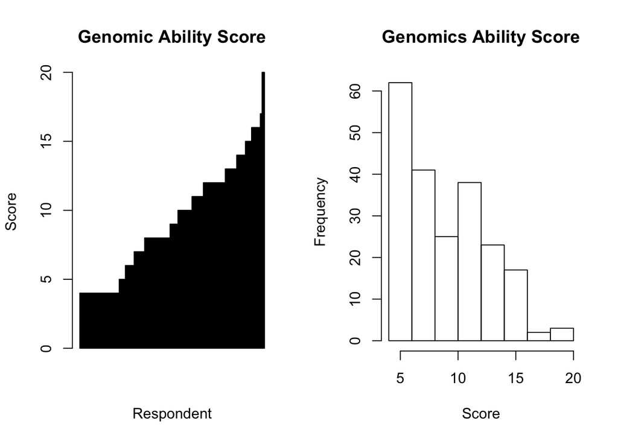

|  | P Value | Bonferroni Significant? | FDR P-value | FDR Significant? |
| --- | --- | --- | --- | --- |
| Question 26 | 0.0996723 | 0 | 0.4983617 | 0 |
| Question 27 | 0.0167090 | 0 | 0.1002542 | 0 |
| Question 28.2 | 0.0000000 | 1 | 0.0000003 | 1 |
| Question 29.1 | 0.2144592 | 0 | 0.5298668 | 0 |
| Question 29.2 | 0.2443243 | 0 | 0.5298668 | 0 |
| Question 30.1 | 0.1324667 | 0 | 0.5298668 | 0 |
| Question 30.2 | 0.1356672 | 0 | 0.5298668 | 0 |

```
##   Q26      mean  N       SD
## 1   1  8.553846 65 4.337449
## 2   2  9.048780 83 3.770917
## 3   3 10.047619 63 3.895525
## 4  NA 12.000000  1       NA
```

```
##   Q27     mean   N       SD
## 1   0 9.851852 109 4.157675
## 2   1 8.524752 101 3.767211
## 3  NA 9.000000   2 4.242641
```

```
##   Q28.2c     mean  N       SD
## 1      1  6.96875 65 4.163213
## 2      2  9.71875 64 3.709570
## 3      3 10.65432 81 3.324757
## 4     NA  6.00000  2 2.828427
```

```
##   Q29.1      mean   N       SD
## 1     0  9.073446 178 4.116241
## 2     1 10.031250  32 3.296962
## 3    NA  8.000000   2 5.656854
```

```
##   Q29.2      mean   N       SD
## 1     1 11.352941  17 3.101233
## 2     2  9.571429   7 2.299068
## 3     3  9.300000  10 4.137901
## 4    NA  8.983051 178 4.094723
```

```
##   Q30.1c      mean   N       SD
## 1      0  9.642857  98 4.367759
## 2      1  8.810811 112 3.591691
## 3   <NA> 10.000000   2 8.485281
```

```
##   Q30.1      mean   N       SD
## 1     0 10.303030  33 4.433430
## 2     1  8.810811 112 3.591691
## 3     2  9.307692  65 4.329849
## 4    NA 10.000000   2 8.485281
```

```
##   Tukey multiple comparisons of means
##     95% family-wise confidence level
##
## Fit: aov(formula = infile3$genomiccomfort ~ as.factor(infile3$Q26))
##
## $`as.factor(infile3$Q26)`
##          diff        lwr      upr     p adj
## 2-1 0.4949343 -1.0696226 2.059491 0.7359054
## 3-1 1.4937729 -0.1718411 3.159387 0.0888407
## 3-2 0.9988386 -0.5795107 2.577188 0.2959205
```

```
##   Tukey multiple comparisons of means
##     95% family-wise confidence level
##
## Fit: aov(formula = infile3$genomiccomfort ~ as.factor(infile3$Q27))
##
## $`as.factor(infile3$Q27)`
##          diff       lwr        upr    p adj
## 1-0 -1.327099 -2.411539 -0.2426596 0.016709
```

```
##   Tukey multiple comparisons of means
##     95% family-wise confidence level
##
## Fit: aov(formula = infile3$genomiccomfort ~ as.factor(infile3$Q28.2c))
##
## $`as.factor(infile3$Q28.2c)`
##         diff        lwr      upr     p adj
## 2-1 2.750000  1.1995767 4.300423 0.0001235
## 3-1 3.685571  2.2187511 5.152391 0.0000000
## 3-2 0.935571 -0.5312489 2.402391 0.2903191
```

```
##   Tukey multiple comparisons of means
##     95% family-wise confidence level
##
## Fit: aov(formula = infile3$genomiccomfort ~ as.factor(infile3$Q29.1))
##
## $`as.factor(infile3$Q29.1)`
##          diff        lwr      upr     p adj
## 1-0 0.9578037 -0.5586374 2.474245 0.2144592
```

```
##   Tukey multiple comparisons of means
##     95% family-wise confidence level
##
## Fit: aov(formula = infile3$genomiccomfort ~ as.factor(infile3$Q30.1c))
##
## $`as.factor(infile3$Q30.1c)`
##           diff       lwr       upr     p adj
## 1-0 -0.8320463 -1.918098 0.2540056 0.1324667
```

### 0.8.1 Difference between means of 18-21 and 22-25

There is a signifificant difference in the mean scores for responses between questions 18-21 and 22-25 (p=2.804936710^{-11}). The mean for the former is 11.8957346; the mean for the latter is 9.2085308.